# Final Project-Heart Disease

## Converting Data

```r
Heart <- HeartDisease %>%
  mutate(sex = if_else(sex == 1, "MALE", "FEMALE"),
         fbs = if_else(fbs == 1, ">120", "<=120"),
         exang = if_else(exang == 1, "YES" ,"NO"),
         cp = if_else(cp == 0, "TYPICAL ANGINA",
                      if_else(cp == 1, "ATYPICAL ANGINA",
                      if_else(cp == 2,"NON-AGINAL PAIN","ASYPMTOMATIC" ))),
         restecg = if_else(restecg == 0, "NORMAL",
                           if_else(restecg == 1, "ABNORMALITY", "PROBABLE OR DEFINITE")),
         slope = as.factor(slope),
         ca = as.factor(ca),
         thal = as.factor(thal),
         target = if_else(target == 1, "YES", "NO")
         ) %>%
  dplyr::select(target, sex, fbs, exang, cp, restecg, slope, ca, thal, everything())
```

## Summary after pre-processing the data

```r
summary(Heart)
```

```
    target              sex                fbs               exang
 Length:1025        Length:1025        Length:1025        Length:1025
 Class :character   Class :character   Class :character   Class :character
 Mode  :character   Mode  :character   Mode  :character   Mode  :character



      cp              restecg          slope   ca      thal
 Length:1025        Length:1025        0: 74   0:578   0:  7
 Class :character   Class :character   1:482   1:226   1: 64
 Mode  :character   Mode  :character   2:469   2:134   2:544
                                               3: 69   3:410
                                               4: 18

      age           trestbps          chol        thalach
 Min.   :29.00   Min.   : 94.0   Min.   :126   Min.   : 71.0
 1st Qu.:48.00   1st Qu.:120.0   1st Qu.:211   1st Qu.:132.0
 Median :56.00   Median :130.0   Median :240   Median :152.0
 Mean   :54.43   Mean   :131.6   Mean   :246   Mean   :149.1
 3rd Qu.:61.00   3rd Qu.:140.0   3rd Qu.:275   3rd Qu.:166.0
 Max.   :77.00   Max.   :200.0   Max.   :564   Max.   :202.0
    oldpeak
 Min.   :0.000
 1st Qu.:0.000
 Median :0.800
 Mean   :1.072
 3rd Qu.:1.800
 Max.   :6.200
```

## Ensuring Data does not Contain NA values

```r
colSums(is.na(Heart))
```

```
  target      sex      fbs    exang       cp  restecg    slope       ca
       0        0        0        0        0        0        0        0
    thal      age trestbps     chol  thalach  oldpeak
       0        0        0        0        0        0
```

### Number of Females vs Males in the Data Set

```r
Heart %>% group_by(sex) %>%
  summarise(count = n())
```

| sex | count |
| --- | --- |
| FEMALE | 312 |
| MALE | 713 |

There are more Males than Females in the Patient Data Set.

### Average Cholestrol for Each Sex

```r
Heart %>% group_by(sex) %>%
  summarise(avgChol = mean(chol))
```

| sex | avgChol |
| --- | --- |
| FEMALE | 261.4551 |
| MALE | 239.2370 |

### Is Patient High or Low Risk

```r
LevelChol <- function(chol){
  if_else(chol <= 200, "Desirable Chol",
                       if_else(chol <= 239,"Borderline high","High risk"))
}
Heart %>% select(sex,age,chol,target) %>%
  mutate(RiskFromChol = LevelChol(chol))
```

| sex | age | chol | target | RiskFromChol |
| --- | --- | --- | --- | --- |
| MALE | 52 | 212 | NO | Borderline high |
| MALE | 53 | 203 | NO | Borderline high |
| MALE | 70 | 174 | NO | Desirable Chol |
| MALE | 61 | 203 | NO | Borderline high |
| FEMALE | 62 | 294 | NO | High risk |
| FEMALE | 58 | 248 | YES | High risk |
| MALE | 58 | 318 | NO | High risk |
| MALE | 55 | 289 | NO | High risk |
| MALE | 46 | 249 | NO | High risk |
| MALE | 54 | 286 | NO | High risk |

[output cut: 990 more lines]

Risk level determined for each patient using their cholestrol.

### Average Cholestral Level Among Sex

```r
Heart %>% group_by(sex,restecg) %>%
  summarise(avgChol = mean(chol))
```

| sex | restecg | avgChol |
| --- | --- | --- |
| FEMALE | ABNORMALITY | 243.6815 |
| FEMALE | NORMAL | 281.9236 |
| FEMALE | PROBABLE OR DEFINITE | 247.1818 |
| MALE | ABNORMALITY | 233.7837 |
| MALE | NORMAL | 243.8442 |
| MALE | PROBABLE OR DEFINITE | 318.0000 |

We have determined the average cholestrol level for each sex depending on their restecg (resting electrocardiographic results).

### Analysis of “Target” Variable

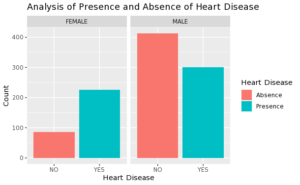

```r
Heart$target <- as.factor(Heart$target)
ggplot(Heart, aes(x=Heart$target, fill=Heart$target)) +
  geom_bar() +
  xlab("Heart Disease") +
  ylab("Count") +
  ggtitle("Analysis of Presence and Absence of Heart Disease") +
  scale_fill_discrete(name = "Heart Disease", labels = c("Absence", "Presence"))+
  facet_grid(.~sex)
```

### Presence of Heart Disease for All Patients

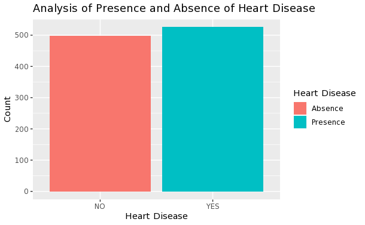

```r
Heart$target <- as.factor(Heart$target)
ggplot(Heart, aes(x=Heart$target, fill=Heart$target)) +
  geom_bar() +
  xlab("Heart Disease") +
  ylab("Count") +
  ggtitle("Analysis of Presence and Absence of Heart Disease") +
  scale_fill_discrete(name = "Heart Disease", labels = c("Absence", "Presence"))
```

From the above plot it is evident that the number of people with presence of CVD is larger than those with absence. Now I must perform further analysis to see what factors lead to heart disease.